# Convolutional Neural Network (CNN)

## 1 Introduction

Les reseaux de neurones convolutifs designent une sous-categorie de reseaux de neurones et sont a ce jour un des modeles de classification d'images reputes etre les plus performan au monde. Leur mode de fonctionnement est a premiere vue simple : l'utilisateur fournit en entree une image sous la forme d'une matrice de pixels. Elle a 2 dimensions pour une image en niveaux de gris. La couleur est representee par une troisieme dimension, de profondeur 3 pour representer les couleurs fondamentales [Rouge, Vert, Bleu].

La disponibilite d'une grande quantite de donnees et l'amelioration de la technologie materielle accelere la recherche sur les CNN, et des architectures CNN approfondies recemment interessantes ont ete signale. Plusieurs idees inspirantes pour faire avancer les CNN ont ete explorees, telles que utilisation de differentes fonctions d'activation et de perte, optimisation des parametres, regularisation et innovations architecturales.

## 2 Synthese de l'article

Cet article passe en revue les progres des architectures CNN, notamment basees sur les modeles de conception des unites de traitement et a propose la taxonomie des architectures CNN recentes. En plus de la categorisation des CNN en differentes classes, cet article couvre egalement l'histoire des CNN, ses applications, ses defis et directions futures. Montre aussi que la capacite d'apprentissage de CNN s'est considerablement amelioree au fil des ans en exploitant profondeur et autres modifications structurelles.

## 3 L'architecture d'un CNN comporte 2 parties

## 3.1 Une partie convolutive

L'objectif final de cette partie est d'extraire des caracteristiques propres a chaque image en les compressant de facon a reduire leur taille initiale. En resume, l'image fournie en entree passe a travers une succession de filtres, creant par la meme occasion de nouvelles images appelees cartes de convolutions. Enfin, les cartes de convolutions obtenues sont concatenees dans un vecteur de caracteristiques appele code CNN.

## 3.2 Une partie classification

Le code CNN obtenu en sortie de la partie convolutive est fourni en entree dans une deuxieme partie, constituee de couches entierement connectees appelees perceptron multicouche (MLP pour Multi Layers Perceptron). Le role de cette partie est de combiner les caracteristiques du code CNN afin de classer l'image.

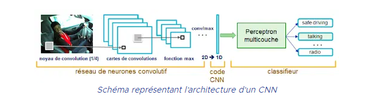

## 4 Methode de sous echantillonnage : le Max-Pooling

Le Max-Pooling est un processus de discretisation base sur des echantillons. Son objectif est de sous-echantillonner une representation d'entree (image, matrice de sortie de couche cachee, etc.) en reduisant sa dimension. De plus, son interet est qu'il reduit le cout de calcul en reduisant le nombre de parametres a apprendre et fournit une invariance par petites translations.

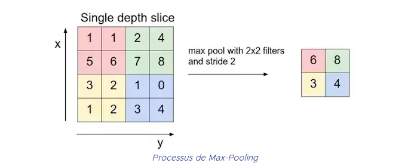

## 5 Les differentes couches d'un CNN

Avant de presenter les differentes couches d'un CNN on va expliquer c'est quoi une Feature.

## 5.1 Une Feature

Une feature est vue comme un filtre : les deux termes sont equivalents dans ce contexte. C'est ou on trouve toute la force des reseaux de neurones convolutifs : ceux-ci sont capables de determiner tout seul les elements discriminants d'une image, en s'adaptant au probleme pose. Par exemple, si la question est de distinguer les chats des chiens, les features automatiquement definies peuvent decrire la forme des oreilles ou des pattes.

## 5.2 Couche de convolution (CONV)

Le role de cette premiere couche est d'analyser les images fournies en entree et de detecter la presence d'un ensemble de features. On obtient en sortie de cette couche un ensemble de features maps. La couche de convolution est la composante cle des reseaux de neurones convolutifs, et constitue toujours au moins leur premiere couche. Son but est de reperer la presence d'un ensemble de features dans les images recues en entree. Pour cela, on realise un filtrage par convolution: le principe est de faire "glisser" une fenetre representant la feature sur l'image, et de calculer le produit de convolution entre la feature et chaque portion de l'image balayee.

## 5.3 Couche de Pooling (POOL) :

La couche de Pooling est une operation generalement appliquee entre deux couches de convolution. Celle-ci recoit en entree les features maps formees en sortie de la couche de convolution et son role est de reduire la taille des images, tout en preservant leurs caracteristiques les plus essentielles. Parmi les plus utilises, on retrouve le max-pooling mentionne precedemment ou encore l'average pooling dont l'operation consiste a conserver a chaque pas, la valeur moyenne de la fenetre de filtre.

## 5.4 La couche d'activation ReLU (Rectified Linear Units) :

Cette couche remplace toutes les valeurs negatives recues en entrees par des zeros. L'interet de ces couches d'activation est de rendre le modele non lineaire et de ce fait plus complexe.

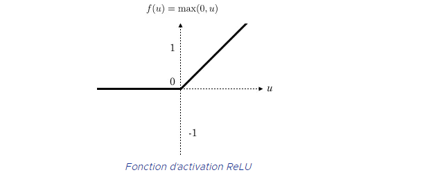

## 5.5 Couche Fully Connected (FC) :

Ces couches sont placees en fin d'architecture de CNN et sont entierement connectees a tous les neurones de sorties (d'ou le terme fully-connected). Apres avoir recu un vecteur en entree, la couche FC applique successivement une combinaison lineaire puis une fonction d'activation dans le but final de classifier l'input image (voir schema suivant). Elle renvoie enfin en sortie un vecteur de taille d correspondant au nombre de classes dans lequel chaque composante represente la probabilite pour l'input image d'appartenir a une classe.

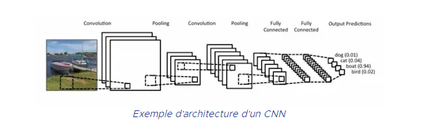

Dans ce contexte, H est une petite image representant le template a retrouver. Concretement, cette operation revient a faire glisser H sur l'image X, a multiplier les pixels qui se superposent et a sommer ces produits. Ainsi, le template matching consiste a calculer la correlation croisee entre une image X et un filtre dont le noyau H represente un template que l'on souhaite retrouver dans X.

## 7 Conclussion

CNN a fait des progres remarquables, en particulier dans le traitement d'image et les taches liees a la vision, et a ainsi ravive l'interet des chercheurs pour les RNA. Dans ce contexte, plusieurs travaux de recherche ont a ete menee pour ameliorer les performances de CNN sur ces taches. Les progrrs des CNN peuvent etre categorise de differentes manieres, y compris l'activation, la fonction de perte, l'optimisation, la regularisation, algorithmes d'apprentissage et innovations en architecture.

## 8 Source

https://blog.octo.com/classification-dimages-les-reseaux-de-neurones-convolutifs-en-toute-simplicite/

https://openclassrooms.com/fr/courses/4470531-classez-et-segmentez-des-donnees-visuelles/5082166-quest-ce-quun-reseau-de-neurones-convolutif-ou-cnn

https://datascientest.com/convolutional-neural-network

https://openclassrooms.com/fr/courses/4470531-classez-et-segmentez-des-donnees-visuelles/5083336-decouvrez-les-differentes-couches-dun-cnn

https://blog.octo.com/classification-dimages-les-reseaux-de-neurones-convolutifs-en-toute-simplicite/

https://openclassrooms.com/fr/courses/4470531-classez-et-segmentez-des-donnees-visuelles/5044811-decouvrez-la-notion-de-features-dans-une-image

https://fr.wikipedia.org/wiki/R%C3%A9seau_neuronal_convolutif

https://medium.com/@CharlesCrouspeyre/comment-les-r%C3%A9seaux-de-neurones-%C3%A0-convolution-fonctionnent-b288519dbcf8